# Q1: what sets how a plate boundary releases slip?

Swarms or mainshock-aftershock sequences, across the offshore Cascadia plate system. Catalog v6.1, plate boundaries v2 (D-B117), D-B114 external data. Decision D-B115. Report built Fri Nov 27 19:43:46 PST 2026. Pre-registration written Fri Nov 27 13:26:14 PST 2026 and committed as 109915b8 (branch science/q1-slip-style) before any covariate correlation was computed.

**Thermal control (T1, T2, T4): inconclusive.** Plate age: cell rho -0.43 (n = 45, one-sided p 0.0016, Holm 0.0080, block 95 % interval -0.78 to +0.29); within boundary types +0.03 (Holm 1.0000). Heat flow: rho +0.30 (n = 29, Holm 0.2372, block -0.16 to +0.72); within types +0.11 (Holm 1.0000).  
Time-shuffle null rule: 4 of 4 hot segments above the null 95th percentile (passed). Uniform-Mc reclustering (Mc 2.15, segments with >= 100 events): hot median 23.5 %, cold median 1.5 %.  
**Fluid signal (T3, in-situ Vp/Vs): not testable.** 7 swarm and 18 mainshock-aftershock families carry a valid Vp/Vs; the test needs 20 of each.

## Boundaries v2 (D-B117)

This version uses the adopted plate boundaries v2. The first version of the report used the D-B113 axes; the table gives the key numbers of both runs, read from their tables.

The verdicts do not change with the v2 boundaries. The boundary moves reassign events between the Gorda Ridge, the Mendocino fault zone and the Gorda plate, and between the Juan de Fuca ridge and plate. The cell tests do not use segments except for the cell type in T4; 0 of the 104 cells change type, so the primary statistics are identical (same events, cells, covariates and seeds). What moves is the segment table, the hot/cold contrast after reclustering, and the segment-level secondary tests.

The rerun recomputed the shuffled-catalog nulls from scratch; their swarm memberships are identical to those of the first run (same seeds), as expected for outputs that do not depend on the segments.

One secondary result changes status: the segment-level correlation of swarm share with plate age goes from -0.79 (BH 0.0847) to -0.93 (BH 0.0154) over 8 oceanic segments. A result that turns on where the boundaries are drawn is weak evidence; this is why the registration made the segment-free cells the primary unit.

| quantity | D-B113 axes (first report) | boundaries v2 (D-B117) |
| --- | --- | --- |
| hot group swarm share | 17.2-29.2 % (Juan de Fuca ridge to Axial; 5 segments) | 18.3-29.2 % (Juan de Fuca ridge to Axial; 5 segments) |
| cold group swarm share | 0.7-2.8 % (Gorda plate to Gorda slab; 4 segments) | 0.7-2.8 % (Gorda plate to Gorda slab; 4 segments) |
| hot / cold median, main run | 24.6 % / 1.1 % | 24.6 % / 1.1 % |
| hot / cold median, reclustered at Mc 2.15 | 23.1 % / 1.6 % | 23.5 % / 1.5 % |
| T1 plate age, cells | -0.43 (n 45, Holm 0.0080, block -0.78 to +0.29) | -0.43 (n 45, Holm 0.0080, block -0.78 to +0.29) |
| T4a plate age within types | +0.03 (n 38, Holm 1.0000) | +0.03 (n 38, Holm 1.0000) |
| T2 heat flow, cells | +0.30 (n 29, Holm 0.2372, block -0.16 to +0.72) | +0.30 (n 29, Holm 0.2372, block -0.16 to +0.72) |
| T4b heat flow within types | +0.11 (n 18, Holm 1.0000) | +0.11 (n 18, Holm 1.0000) |
| segment swarm share vs plate age (secondary, BH) | -0.79 (n 8, BH 0.0847, not significant) | -0.93 (n 8, BH 0.0154, significant) |
| control runs with the predicted age sign | 22 / 22 | 22 / 22 |
| time-shuffle null rule (hot segments above p95) | 4 of 4 | 4 of 4 |
| verdict, thermal control | inconclusive | inconclusive |
| verdict, Vp/Vs | not testable | not testable |
| Gorda Ridge swarm share (event-set events) | 19.5 % of 559 | 20.3 % of 537 |
| Mendocino fault zone swarm share (event-set events) | 1.2 % of 729 | 1.1 % of 802 |
| Gorda plate swarm share (event-set events) | 0.7 % of 1,836 | 0.7 % of 1,785 |
| Juan de Fuca ridge swarm share (event-set events) | 17.2 % of 366 | 18.3 % of 360 |
| Juan de Fuca plate swarm share (event-set events) | 1.8 % of 164 | 0.0 % of 170 |

## 1. Question and hypothesis

**Question.** What sets how a plate boundary releases slip: in swarms, or in mainshock-aftershock sequences?

**Working hypothesis (H1).** Release is swarm-dominated where the lithosphere is young, hot, magmatic or fluid-rich (ridges, the Blanco pull-aparts, Mount St Helens) and mainshock-aftershock-dominated where it is colder and stronger (Gorda plate, Mendocino fault zone, Gorda slab). In testable form: the share of earthquakes in swarms rises with thermal state (younger plate, higher heat flow, shallower isotherms) and with fluid content (higher in-situ Vp/Vs), and it does so across spatial cells drawn without the segment boundaries, not only as a contrast between boundary types.

What was known before the registration (as written in it), and so cannot confirm H1: the v6.1 plate-boundary table of 10:07 PST (PB2002 segments) gave swarm shares of 29 % at Axial, 28 % at Mount St Helens, 25 % at Blanco and 19 % on the Gorda Ridge, against 2.8 % or less at the Mendocino fault zone, Gorda plate, triple junction and Gorda slab. That contrast is where H1 came from. It is shown below for completeness, but it carries no test.

## 2. Pre-registered tests

Written Fri Nov 27 13:26:14 PST 2026 in `data/paper_plan/q1_slip_style/RESUME.md` and committed (109915b8) before any covariate was sampled. Event set: located earthquakes (event_flag empty, so blasts, explosions and the Mount St Helens analog test signal are out), tiers A-C, not in the waveform-review set P1, at or above the regional Mc of the v6.1 nearest-neighbour clustering. Swarm share = percentage of these events that belong to families typed swarm.

| test | unit | statistic | prediction | p-value |
| --- | --- | --- | --- | --- |
| T1 | 0.2 deg cells (>= 50 events) | swarm share vs plate age | rho < 0 | one-sided permutation |
| T2 | 0.2 deg cells | swarm share vs heat flow | rho > 0 | one-sided permutation |
| T3 | families | Vp/Vs, swarm minus mainshock-aftershock | > 0 | labels permuted within boundary type; needs >= 20 + 20 families |
| T4a | 0.2 deg cells | within-type rho, swarm share vs age | < 0 | covariate permuted within type |
| T4b | 0.2 deg cells | within-type rho, swarm share vs heat flow | > 0 | covariate permuted within type |

Holm correction over these five tests (alpha 0.05). Secondary tests (b, productivity, family mix, background fraction against age and heat flow; swarm share against spreading rate; segment-level correlations) share one Benjamini-Hochberg family; roughness, sediment, the isotherm depth and the slab-surface temperature are exploratory. Every cell-level rho also has a 95 % interval from bootstraps of 1 x 1 degree blocks of cells.

**Decision rules.** D1 (thermal control supported): T1 or T2 significant after Holm with the predicted sign, its block interval excludes 0, the same sign in at least 18 of the 22 control runs, and the time-shuffle null rule passes (at least 3 of Axial, Blanco, Gorda Ridge and Mount St Helens above the 95th percentile of their swarm share in time-shuffled catalogs). D2 (beyond boundary type): D1 plus the matching T4. D3 (fluid signal): T3 significant. Falsified: T1 and T2 both reversed with two-sided p < 0.05, or the hot group not above the cold group after reclustering at a uniform Mc, or the null rule failing; for Vp/Vs, mainshock-aftershock families above swarm families with two-sided p < 0.05. Anything else is inconclusive.

## 3. Data

| input | source | use |
| --- | --- | --- |
| Catalog v6.1 | cascadia_catalog_v6.1.csv, md5 1cd909b5 | 25,948 events in the event set (tiers A-C, earthquakes, above the regional Mc) |
| Clustering v6.1 | v51_clusters_zbz.py --catalog v6.1 (Zaliapin and Ben-Zion nearest-neighbour; nine regions) | families typed swarm / mainshock-aftershock / multiplet; 12 sensitivity variants |
| Mc maps v6.1 | magnitude_converged/mc_maps_v61 (non-earthquakes out) | mc_best per 0.1 deg node (controls) |
| Segments | pb_common.assign_segments, plate boundaries v2 adopted (D-B117), recomputed in q1_metrics.py | 18 segments with >= 100 events |
| Cells | 0.2 x 0.2 deg from 132 W, 38 N | 104 cells with >= 50 events |
| External covariates | D-B114 events_external_geo_v61.parquet; PROVENANCE.csv | Seton et al. 2020 age and full rate (doi 10.1029/2020GC009214); GHFDB R2024 (10.5880/fidgeo.2024.014); GlobSed v3 (10.1029/2018GC008115); GEBCO 2026 + GMRT |
| CC differential times | tomo_v1/cc_dt_all (v5.1 families, D-B093) | 2,097 v5.1 families; 1,785 carry over to one v6.1 family (>= 50 % of members) |

## 4. Results

### 4.1 Segments

Swarm share above Mc separates two groups of segments. The hot group (Axial, the Juan de Fuca ridge, the Gorda Ridge, Blanco and Mount St Helens) puts 18.3-29.2 % of its earthquakes in swarms; the cold group (the Gorda plate, the Mendocino fault zone, the triple junction and the Gorda slab) 0.7-2.8 %. The lowest hot segment (Juan de Fuca ridge, 18.3 %) is 6.5 times the highest cold segment (Gorda slab, 2.8 %). The other segments range from 0.0 % (Juan de Fuca plate) to 15.4 % (Cascade arc). This contrast generated the hypothesis, so it is described here, not tested. b ranges from 0.74 (Juan de Fuca slab) and 0.80 (Axial) to 1.41 (Gorda Ridge) and 1.45 (Puget); it does not split along the hot and cold groups (Axial 0.80, Gorda Ridge 1.41). Productivity (direct offspring of events 1-2 units above Mc) is highest at Blanco (1.53) and Puget (1.42) and lowest at the Mendocino fault zone (0.24) and the Juan de Fuca slab (0.13): in swarm settings the chain-like families give each event offspring, so this measure does not isolate aftershock productivity.

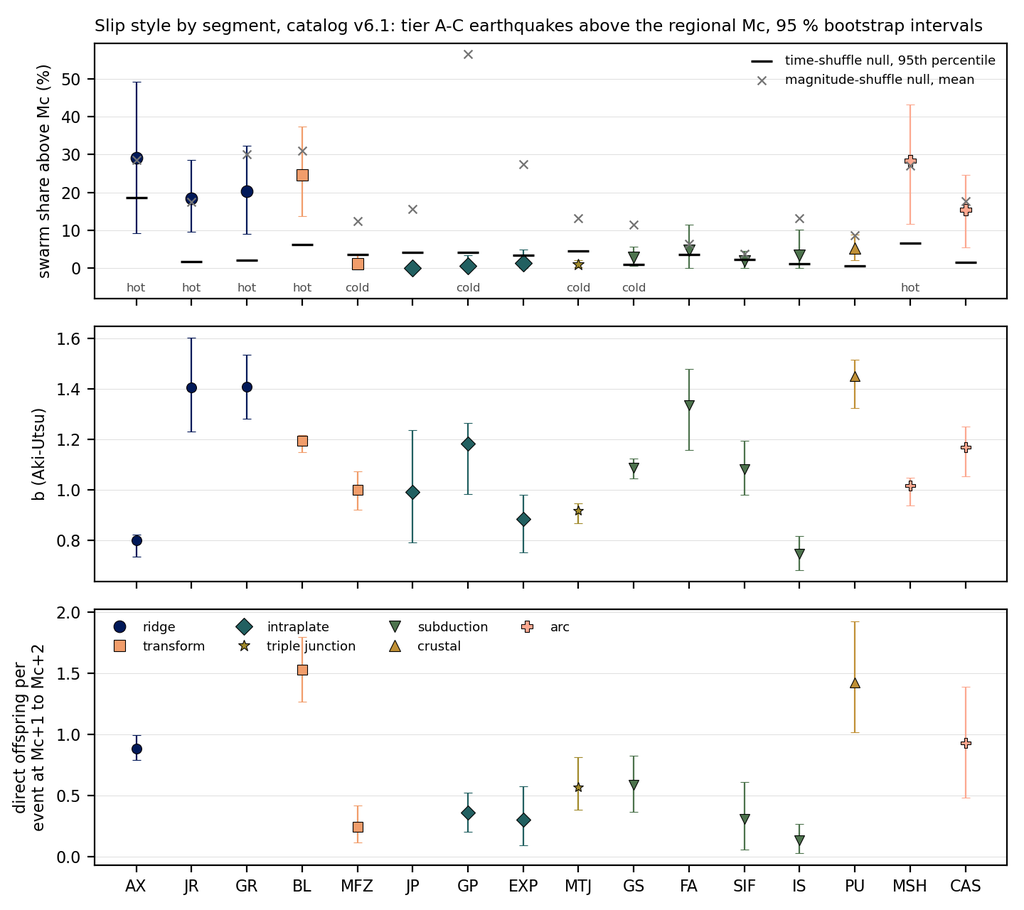

Swarm share, b and productivity per segment (plate boundaries v2, >= 100 events). Bars: 95 % bootstrap intervals (families resampled as whole units for the swarm share; events for b; parent events for productivity). Black ticks: 95th percentile of the swarm share in 100 time-shuffled catalogs. Crosses: mean swarm share when magnitudes are shuffled within each clustering region and the families are retyped. Colours: batlowS by segment type with one marker per type.

| seg | group | type | events | swarm % | lo | hi | background % | swarm fam. share | b | lo | hi | productivity | swarm duration (d) | migrating / swarms n>=10 | age (Myr) | heat flow | time-null p95 | mag-null mean |
| --- | --- | --- | --- | --- | --- | --- | --- | --- | --- | --- | --- | --- | --- | --- | --- | --- | --- | --- |
| AX | hot | ridge | 2,506 | 29.2 | 9.1 | 49.2 | 49.6 | 0.67 | 0.80 | 0.73 | 0.82 | 0.88 | 0.03 | 3/11 | 0.07 | - | 18.6 | 28.6 |
| JR | hot | ridge | 360 | 18.3 | 9.6 | 28.4 | 54.7 | 0.91 | 1.41 | 1.23 | 1.60 | - | 2.67 | 0/1 | 0.14 | 180 | 1.7 | 17.5 |
| GR | hot | ridge | 537 | 20.3 | 9.0 | 32.4 | 44.5 | 0.59 | 1.41 | 1.28 | 1.53 | - | 1.05 | 2/4 | 0.09 | - | 2.1 | 30.0 |
| BL | hot | transform | 8,571 | 24.6 | 13.7 | 37.3 | 47.6 | 0.67 | 1.19 | 1.15 | 1.22 | 1.53 | 0.55 | 3/28 | 0.68 | - | 6.2 | 31.0 |
| MFZ | cold | transform | 802 | 1.1 | 0.0 | 3.6 | 71.6 | 0.14 | 1.00 | 0.92 | 1.07 | 0.24 | 2.27 | - | 3.80 | - | 3.6 | 12.5 |
| JP |  | intraplate | 170 | 0.0 | 0.0 | 0.0 | 55.9 | - | 0.99 | 0.79 | 1.24 | - | - | - | 6.09 | - | 4.2 | 15.6 |
| GP | cold | intraplate | 1,785 | 0.7 | 0.0 | 3.4 | 32.3 | 0.22 | 1.18 | 0.98 | 1.26 | 0.36 | 2.49 | - | 4.55 | - | 4.1 | 56.5 |
| EXP |  | intraplate | 391 | 1.3 | 0.0 | 4.8 | 38.1 | 0.17 | 0.88 | 0.75 | 0.98 | 0.30 | 0.87 | - | 2.59 | 222 | 3.3 | 27.4 |
| MTJ | cold | triple junction | 2,313 | 1.0 | 0.2 | 2.0 | 64.1 | 0.21 | 0.92 | 0.87 | 0.95 | 0.57 | 0.60 | - | - | 75 | 4.5 | 13.2 |
| GS | cold | subduction | 1,663 | 2.8 | 0.7 | 5.6 | 68.3 | 0.43 | 1.09 | 1.05 | 1.12 | 0.59 | 2.53 | 0/2 | - | 54 | 0.9 | 11.5 |
| FA |  | subduction | 171 | 4.7 | 0.0 | 11.5 | 68.4 | - | 1.33 | 1.16 | 1.48 | - | 19.93 | - | - | - | 3.5 | 6.3 |
| SIF |  | subduction | 384 | 1.8 | 0.0 | 4.6 | 88.5 | - | 1.08 | 0.98 | 1.19 | 0.31 | 216.11 | - | - | - | 2.3 | 3.8 |
| IS |  | subduction | 486 | 3.5 | 0.0 | 10.2 | 64.6 | 0.67 | 0.74 | 0.68 | 0.82 | 0.13 | 12.94 | 0/1 | - | - | 1.2 | 13.1 |
| PU |  | crustal | 2,805 | 5.2 | 2.2 | 8.8 | 73.6 | 0.44 | 1.45 | 1.32 | 1.52 | 1.42 | 38.28 | 0/5 | - | - | 0.7 | 8.7 |
| MSH | hot | arc | 243 | 28.4 | 11.7 | 43.1 | 39.1 | 0.79 | 1.02 | 0.94 | 1.05 | - | 12.55 | 2/6 | - | 45 | 6.6 | 27.1 |
| CAS |  | arc | 1,017 | 15.4 | 5.5 | 24.5 | 63.8 | 0.61 | 1.17 | 1.05 | 1.25 | 0.93 | 33.82 | 0/9 | - | 60 | 1.6 | 17.7 |
| OC |  | other | 701 | 0.9 | 0.0 | 2.9 | 81.9 | 0.20 | 1.11 | 1.09 | 1.26 | 0.43 | 0.51 | - | - | 41 | 0.0 | 3.4 |
| NAPA |  | other | 918 | 2.3 | 0.2 | 5.0 | 74.9 | 0.33 | 0.88 | 0.83 | 0.93 | 0.37 | 1.27 | - | - | 59 | 0.7 | 5.6 |

Swarm duration: median over swarm families with >= 5 events. Age and heat flow: median of the D-B114 values over the segment's events (empty when fewer than half carry a value).

### 4.2 Spatial cells and the primary tests

104 cells of 0.2 degree hold at least 50 events. Plate age exists in 45 of them (oceanic crust in the age grid: ridges, Blanco, the Mendocino fault zone, the Gorda plate and 2 triple-junction cells), heat flow in 29 (mostly onshore and around the triple junction; the smoothed field has no value at Blanco and Axial).

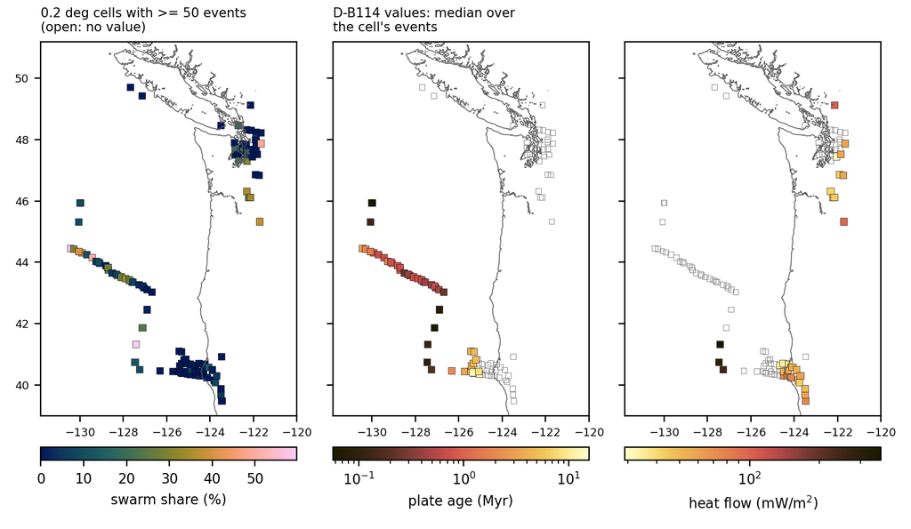

Cells with >= 50 events: swarm share, plate age and heat flow (D-B114 values, median over the cell's events). Open squares: no value. Crameri batlow and lajolla.

**T1, plate age.** rho = -0.43 over 45 cells, one-sided p = 0.0016, Holm-adjusted 0.0080: significant with the predicted sign. The 1 x 1 degree block bootstrap gives a 95 % interval of -0.78 to +0.29, which includes 0. The 45 cells fall in 14 blocks, and the signal comes from one contrast. Of the 13 cells older than 2 Myr, one has swarm events (a Blanco cell at 2.9 Myr, swarm share 59 %) and the other 12 (the Gorda plate, the Mendocino fault zone and the triple junction) have none. The cells younger than 2 Myr (ridges and Blanco) have a median swarm share of 10.5 %.

**T4a, plate age within boundary types.** Weighted within-type rho = +0.03, one-sided p = 0.5645 (Holm 1.0000). Per type: intraplate constant (5 cells); ridge +0.36 (7 cells); transform -0.05 (31 cells). The 31 transform cells are 25 Blanco and 6 Mendocino fault zone cells. Looked at after the test (not registered): the 25 Blanco cells alone (0.2-2.9 Myr, swarm share 0-59 %) give rho +0.51, the opposite sign to the prediction. The quasi-binomial model with type terms gives -1.25 +- 0.84 on the logit scale per standard deviation of age (dispersion 44).

**T2 and T4b, heat flow.** rho = +0.30 over 29 cells, one-sided p = 0.0593, Holm 0.2372; block interval -0.16 to +0.72. Within types +0.11 (Holm 1.0000; arc +0.41 (6 cells); other -0.35 (7 cells); subduction +0.40 (5 cells)); the type-controlled model does not converge (types whose cells have no swarms separate the data), so it gives no effect size. With the interim heat-flow sampler (median of GHFDB sites within 25 km) T2 is -0.01: the heat-flow result depends on how sparse site values are spread to the events (with the interim values the heat-flow sign holds in 10 of 22 control runs, against 21 with the D-B114 field).

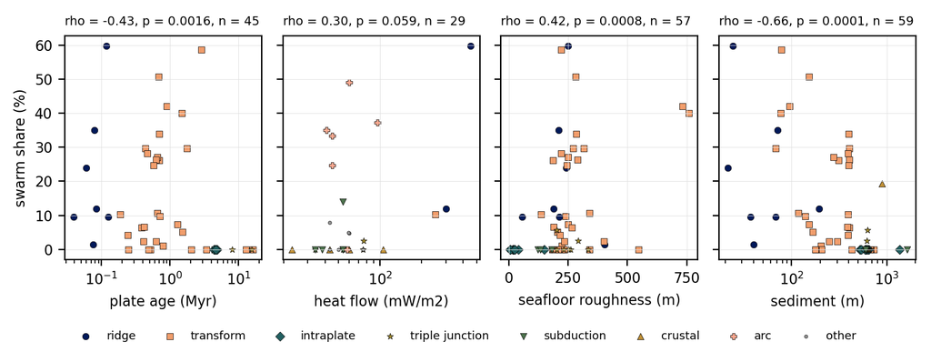

Cell swarm share against plate age and heat flow (primary covariates) and against roughness and sediment thickness (exploratory). rho and p: Spearman and its permutation p (one-sided where a sign was predicted).

| test | covariate | statistic | n | p (one-sided) | Holm p | block lo | block hi | significant (Holm) | predicted sign |
| --- | --- | --- | --- | --- | --- | --- | --- | --- | --- |
| T1 | age_myr | -0.433 | 45 | 0.0016 | 0.0080 | -0.78 | 0.29 | yes | yes |
| T2 | heatflow_mw | 0.296 | 29 | 0.0593 | 0.2372 | -0.16 | 0.72 | no | yes |
| T4a | age_myr | 0.026 | 38 | 0.5645 | 1.0000 | - | - | no | no |
| T4b | heatflow_mw | 0.108 | 18 | 0.3517 | 1.0000 | - | - | no | yes |
| T3 | family type | - | 25 | - | 1.0000 | - | - | no | no |

T3 statistic: difference of median Vp/Vs, swarm minus mainshock-aftershock families; empty when the test is not testable (it needs 20 families of each type).

### 4.3 Secondary and exploratory tests

| family | unit | metric | covariate | predicted sign | rho | n | p | BH p | significant (BH) |
| --- | --- | --- | --- | --- | --- | --- | --- | --- | --- |
| secondary | cell | b | age_myr | -1 | -0.346 | 40 | 0.0154 | 0.0847 | no |
| secondary | cell | b | heatflow_mw | 1 | 0.208 | 26 | 0.1552 | 0.5690 | no |
| secondary | cell | productivity | age_myr | 1 | -0.608 | 12 | 0.9822 | 0.9925 | no |
| secondary | cell | productivity | heatflow_mw | -1 | - | 3 | - | - | no |
| secondary | cell | fam_mix | age_myr | -1 | 0.241 | 20 | 0.8540 | 0.9925 | no |
| secondary | cell | fam_mix | heatflow_mw | 1 | -0.264 | 7 | 0.7322 | 0.9925 | no |
| secondary | cell | bg_frac | age_myr | 0 | 0.155 | 45 | 0.3147 | 0.8653 | no |
| secondary | cell | bg_frac | heatflow_mw | 0 | -0.017 | 29 | 0.9281 | 0.9925 | no |
| secondary | cell | swarm_share | rate_mmyr | 1 | -0.376 | 41 | 0.9925 | 0.9925 | no |
| secondary | seg | swarm_share | age_myr | -1 | -0.929 | 8 | 0.0014 | 0.0154 | yes |
| secondary | seg | swarm_share | heatflow_mw | 1 | -0.486 | 6 | 0.8465 | 0.9925 | no |
| secondary | seg | swarm_share | rate_mmyr | 1 | -0.286 | 8 | 0.7673 | 0.9925 | no |
| secondary | seg | swarm_share | vpvs_fam | 1 | - | 4 | - | - | no |
| exploratory | cell | swarm_share | rough_m | 0 | 0.420 | 57 | 8.0e-04 | 0.0056 | yes |
| exploratory | seg | swarm_share | rough_m | 0 | 0.450 | 9 | 0.2326 | 0.2713 | no |
| exploratory | cell | swarm_share | sed_m | 0 | -0.663 | 59 | 1.0e-04 | 0.0014 | yes |
| exploratory | seg | swarm_share | sed_m | 0 | -0.600 | 10 | 0.0720 | 0.1260 | no |
| exploratory | cell | swarm_share | z600_km | -1 | -0.436 | 45 | 0.0017 | 0.0073 | yes |
| exploratory | seg | swarm_share | z600_km | -1 | -0.910 | 8 | 0.0021 | 0.0073 | yes |
| exploratory | cell | swarm_share | Tslab_C | 0 | 0.187 | 50 | 0.1880 | 0.2392 | no |
| exploratory | seg | swarm_share | Tslab_C | 0 | 0.833 | 8 | 0.0153 | 0.0357 | yes |
| exploratory | cell | b | rough_m | 0 | 0.201 | 49 | 0.1644 | 0.2301 | no |
| exploratory | cell | b | sed_m | 0 | -0.366 | 51 | 0.0087 | 0.0244 | yes |
| exploratory | cell | productivity | rough_m | 0 | 0.371 | 16 | 0.1592 | 0.2301 | no |
| exploratory | cell | productivity | sed_m | 0 | -0.594 | 16 | 0.0184 | 0.0368 | yes |
| exploratory | cell | bg_frac | rough_m | 0 | -0.005 | 57 | 0.9694 | 0.9694 | no |
| exploratory | cell | bg_frac | sed_m | 0 | 0.094 | 59 | 0.4885 | 0.5260 | no |

One of the 11 secondary tests passes the Benjamini-Hochberg threshold. The two smallest BH values: swarm share against plate age (8 segments, rho -0.93, BH 0.015, predicted sign, significant); b against plate age (40 cells, rho -0.35, BH 0.085, predicted sign). Productivity against age has the opposite sign to the prediction (rho -0.61, 12 cells). Among the exploratory covariates, the swarm share changes with sediment thickness (cells, rho -0.66) and roughness (rho +0.42). Both follow the same geography as age (thin sediment and rough, young seafloor at the ridges and Blanco; thick sediment on the Gorda plate and near the margin), so they describe the same contrast and were not predicted. The 600 C isotherm depth has the ranks of plate age (rho -0.44; as registered it is not a separate test). The slab-surface temperature gives rho +0.83 over 8 segments and +0.19 over cells: the hot-slab segments are the arc segments far from the trench, so this is the arc-forearc contrast again.

### 4.4 In-situ Vp/Vs of earthquake families

Of the 2,097 v5.1 families, 1,785 carry over to one v6.1 family (that family holds >= 50 % of their members). With the registered rules (CC-accepted P and S at >= 3 common stations per pair, pairs within 5 km, >= 5 events and >= 30 points per family), 245 families give an estimate and 27 are valid (95 % half-width <= 0.10, value within 1.4-2.5): 7 swarm, 18 mainshock-aftershock and 2 multiplet families. T3 is therefore not testable. None of the valid families is on a ridge; the most are in the mendocino CC block (8).

Two measurement limits explain the low yield. First, regression dilution: within a family the demeaned P differential times spread over only about 10 ms (median interquartile range), close to the CC noise (median residual MAD 5 ms). The L1 slope then falls toward zero as noise grows: the median estimate rises from 0.30 in the lowest fifth of signal-to-noise to 1.67 in the highest fifth, where the valid values span 1.41-1.84. Second, at Axial the S-P time is about 0.5 s, so the S window (-0.3 to +1.0 s around S) contains P energy; the 56 Axial estimates have a median of 0.90, below any rock value, with a median half-width of 0.24. Catalog picks (the registered fallback) are worse: their noise exceeds the spread, the median estimate is 0.17 and 2 families are valid. The 11-25 feasibility count (621 families) counted catalog picks only and did not check precision.

For the record, not as a test: the valid swarm families have a median Vp/Vs of 1.65 (n = 7) and the mainshock-aftershock families 1.73 (n = 18), the opposite order to the hypothesis, on too few families to mean anything.

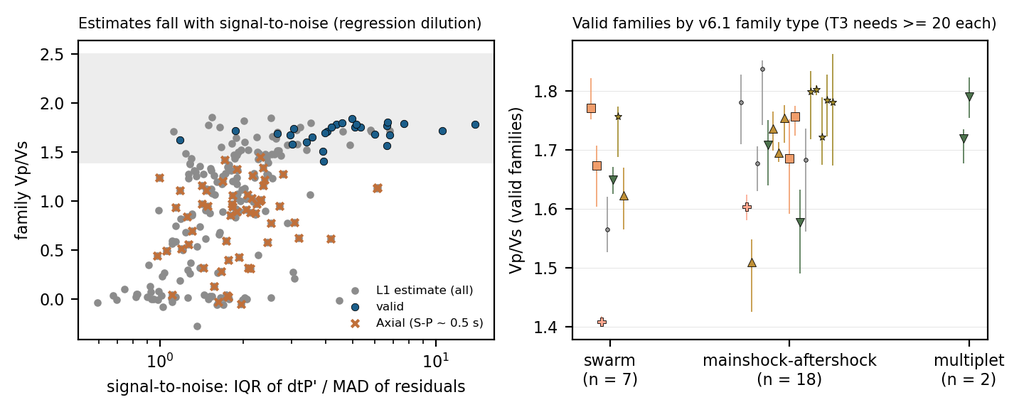

Left: family Vp/Vs (L1 slope of demeaned S on P CC differential times) against signal-to-noise; grey band: the registered valid range; crosses: Axial, where S-P is about 0.5 s. Right: valid families by v6.1 type, with 95 % bootstrap intervals; markers and colours by segment type.

## 5. Controls

**Sign stability.** The cell rho of swarm share against plate age has the predicted sign in 22 of 22 control runs; against heat flow in 21 of 22 (exceptions: v60). The size is less stable than the sign: with plate age, rho ranges from -0.06 (N100, 27 cells) and -0.10 (var_mc+0.3) to -0.50 (N30), and the runs that thin the cells (mcu_count, mcu_recluster, mc_local, ci_window, cell04) give -0.34 to -0.25 with one-sided p of 0.039-0.06.

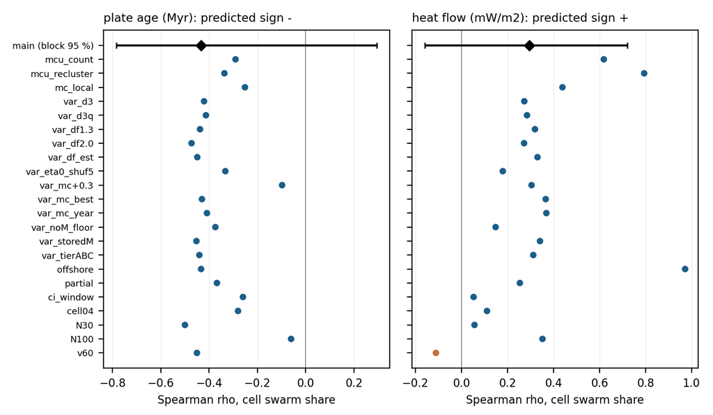

Spearman rho of cell swarm share with plate age and heat flow in the main run (black, with the 1 x 1 degree block-bootstrap 95 % interval) and in the 22 control runs (blue: predicted sign; orange: opposite sign).

| control run | rho age | p | cells | rho heat flow | p | cells |
| --- | --- | --- | --- | --- | --- | --- |
| mcu_count | -0.291 | 0.0540 | 29 | 0.619 | 0.0345 | 9 |
| mcu_recluster | -0.337 | 0.0395 | 29 | 0.794 | 0.0095 | 9 |
| mc_local | -0.252 | 0.0600 | 39 | 0.439 | 0.0105 | 26 |
| var_d3 | -0.421 | 0.0035 | 45 | 0.273 | 0.0825 | 29 |
| var_d3q | -0.413 | 0.0025 | 45 | 0.285 | 0.0600 | 29 |
| var_df1.3 | -0.438 | 0.0020 | 45 | 0.320 | 0.0430 | 29 |
| var_df2.0 | -0.473 | 0.0025 | 45 | 0.272 | 0.0825 | 29 |
| var_df_est | -0.449 | 0.0020 | 45 | 0.331 | 0.0345 | 29 |
| var_eta0_shuf5 | -0.333 | 0.0145 | 45 | 0.180 | 0.1819 | 29 |
| var_mc+0.3 | -0.098 | 0.3168 | 26 | 0.305 | 0.1999 | 9 |
| var_mc_best | -0.430 | 1.0e-03 | 68 | 0.366 | 0.0020 | 54 |
| var_mc_year | -0.409 | 1.0e-03 | 51 | 0.369 | 1.0e-03 | 67 |
| var_noM_floor | -0.374 | 5.0e-04 | 69 | 0.148 | 0.1639 | 45 |
| var_storedM | -0.453 | 0.0025 | 45 | 0.342 | 0.0345 | 30 |
| var_tierABC | -0.441 | 0.0020 | 45 | 0.312 | 0.0570 | 29 |
| offshore | -0.433 | 0.0025 | 45 | 0.972 | 1.0e-03 | 7 |
| partial | -0.368 | 0.0090 | 45 | 0.254 | 0.0945 | 29 |
| ci_window | -0.260 | 0.0530 | 39 | 0.053 | 0.4423 | 15 |
| cell04 | -0.280 | 0.0520 | 32 | 0.111 | 0.2789 | 29 |
| N30 | -0.500 | 5.0e-04 | 65 | 0.057 | 0.3518 | 45 |
| N100 | -0.060 | 0.3678 | 27 | 0.352 | 0.1504 | 11 |
| v60 | -0.451 | 0.0015 | 43 | -0.111 | 0.6802 | 20 |

mcu_count: only M >= 2.15 events counted, main families. mcu_recluster: clustering redone with Mc 2.15 in every region. mc_local: events at or above the Mc map value of their 0.1 degree node. var_*: the 12 v6.1 clustering variants. offshore: cells with most events offshore. partial: partial rank correlation controlling for the Mc map value and the distance to the nearest station. ci_window: 2011-10 to 2015-09 only. cell04: 0.4 degree cells. N30 / N100: other minimum event counts. v60: catalog v6.0, its clustering and the same segment rule (interim covariates on the v6.0 positions).

**Completeness, clustering parameters and catalog version (hot against cold segments).** The lowest hot segment stays above the highest cold segment in 18 of 18 runs. With the clustering redone at a uniform Mc of 2.15 (Axial keeps 276 tier A-C events above it), the hot median is 23.5 % and the cold median 1.5 %, so the falsification rule on completeness does not apply. The segment swarm shares of v6.0 and v6.1 have a rank correlation of 0.98 (same segment rule on both); Mount St Helens moves from 38 % to 28 % (one family retyped, D-B111 family instability).

| run | hot segments | hot median % | hot min % | cold segments | cold median % | cold max % | min hot > max cold |
| --- | --- | --- | --- | --- | --- | --- | --- |
| main | 5 | 24.6 | 18.3 | 4 | 1.1 | 2.8 | yes |
| v60 | 5 | 23.8 | 15.8 | 4 | 0.9 | 3.4 | yes |
| mcu_count | 4 | 30.6 | 21.5 | 4 | 1.9 | 4.8 | yes |
| mcu_recluster | 4 | 23.5 | 13.0 | 4 | 1.5 | 2.1 | yes |
| mc_local | 5 | 24.5 | 20.3 | 4 | 1.1 | 2.9 | yes |
| ci_window | 5 | 21.0 | 18.5 | 4 | 1.2 | 3.8 | yes |
| var_d3 | 5 | 22.7 | 16.2 | 4 | 1.1 | 4.0 | yes |
| var_d3q | 5 | 23.9 | 19.4 | 4 | 1.1 | 2.9 | yes |
| var_df1.3 | 5 | 21.0 | 11.4 | 4 | 1.1 | 1.4 | yes |
| var_df2.0 | 5 | 23.3 | 17.8 | 4 | 1.6 | 4.0 | yes |
| var_df_est | 5 | 20.3 | 8.9 | 4 | 1.2 | 1.6 | yes |
| var_eta0_shuf5 | 5 | 15.6 | 5.3 | 4 | 0.7 | 1.0 | yes |
| var_mc+0.3 | 5 | 21.8 | 12.1 | 4 | 0.8 | 2.4 | yes |
| var_mc_best | 6 | 21.8 | 9.5 | 4 | 1.7 | 2.9 | yes |
| var_mc_year | 5 | 16.7 | 9.3 | 4 | 1.2 | 3.3 | yes |
| var_noM_floor | 5 | 22.7 | 16.8 | 4 | 1.5 | 3.8 | yes |
| var_storedM | 5 | 25.8 | 23.9 | 4 | 1.0 | 3.5 | yes |
| var_tierABC | 5 | 24.5 | 15.3 | 4 | 1.2 | 2.6 | yes |

**Shuffled-catalog nulls.** Time shuffle (100 catalogs, event times permuted within each clustering region, real thresholds): Axial, Blanco, the Gorda Ridge and Mount St Helens lie above the 95th percentile of their null swarm share, so the null rule passes (4 of 4). Dense seismicity alone makes swarms at Axial (null mean 14.7 %, observed 29.2 %); elsewhere the null mean is 0.0-3.5 %. Magnitude shuffle (200 draws, family membership and trees kept): in the cold segments the observed swarm share is below the 5th percentile of the magnitude-shuffle null (Gorda plate 0.7 % against 57 %; Mendocino fault zone 1.1 % against 12 %; triple junction 1.0 % against 13 %; Gorda slab 2.8 % against 12 %), so their families carry a dominant mainshock far more often than random magnitudes would give. At Axial, the Juan de Fuca ridge, Mount St Helens and the Cascade arc the observed share is not below that range: their families look like random draws in magnitude. The Gorda Ridge and Blanco sit in between (below the 5th percentile, at 20 % and 25 %).

| seg | events | observed % | time-null mean % | time-null p95 % | above p95 | mag-null mean % | mag-null p05 % | below mag-null p05 |
| --- | --- | --- | --- | --- | --- | --- | --- | --- |
| AX | 2,506 | 29.2 | 14.7 | 18.6 | yes | 28.6 | 11.8 | no |
| JR | 360 | 18.3 | 0.3 | 1.7 | yes | 17.5 | 13.1 | no |
| GR | 537 | 20.3 | 0.3 | 2.1 | yes | 30.0 | 22.9 | yes |
| BL | 8,571 | 24.6 | 3.5 | 6.2 | yes | 31.0 | 25.6 | yes |
| MFZ | 802 | 1.1 | 1.0 | 3.6 | no | 12.5 | 7.6 | yes |
| JP | 170 | 0.0 | 0.7 | 4.2 | no | 15.6 | 0.0 | no |
| GP | 1,785 | 0.7 | 1.6 | 4.1 | no | 56.5 | 1.7 | yes |
| EXP | 391 | 1.3 | 1.1 | 3.3 | no | 27.4 | 4.6 | yes |
| MTJ | 2,313 | 1.0 | 2.1 | 4.5 | no | 13.2 | 7.0 | yes |
| GS | 1,663 | 2.8 | 0.4 | 0.9 | yes | 11.5 | 4.9 | yes |
| FA | 171 | 4.7 | 0.7 | 3.5 | yes | 6.3 | 3.5 | no |
| SIF | 384 | 1.8 | 0.7 | 2.3 | no | 3.8 | 2.3 | yes |
| IS | 486 | 3.5 | 0.2 | 1.2 | yes | 13.1 | 2.3 | no |
| PU | 2,805 | 5.2 | 0.1 | 0.7 | yes | 8.7 | 6.8 | yes |
| MSH | 243 | 28.4 | 2.7 | 6.6 | yes | 27.1 | 18.5 | no |
| CAS | 1,017 | 15.4 | 0.7 | 1.6 | yes | 17.7 | 14.2 | no |
| OC | 701 | 0.9 | 0.0 | 0.0 | yes | 3.4 | 1.6 | yes |
| NAPA | 918 | 2.3 | 0.1 | 0.7 | yes | 5.6 | 3.5 | yes |

## 6. What the paper can claim, and what it cannot

**Pre-registered outcome.** Thermal control: inconclusive (T1 is significant with the predicted sign, the null rule passes, the sign holds in 22 of 22 control runs, but the block-bootstrap interval of T1 includes 0, so D1 fails; T4a gives +0.03 within boundary types). Falsification rules: none applies. Fluid signal: not testable.

### The paper can claim

- Slip style splits by boundary setting: 18-29 % of earthquakes above Mc are in swarms at Axial, the Juan de Fuca ridge, the Gorda Ridge, Blanco and Mount St Helens, against 0.7-2.8 % at the Gorda plate, the Mendocino fault zone, the triple junction and the Gorda slab. The split survives a uniform Mc of 2.15 (reclustered: hot median 23.5 %, cold median 1.5 %), the 12 clustering variants and catalog v6.0 (lowest hot above highest cold in 18 of 18 runs), and a time-shuffle null.
- At the Gorda plate, the Mendocino fault zone, the triple junction and the Gorda slab the families carry a dominant mainshock far more often than random magnitude ordering would give (swarm share below the 5th percentile of a magnitude-shuffle null), while at Axial, the Juan de Fuca ridge and Mount St Helens the families cannot be told apart from random magnitude ordering.
- Across 45 oceanic 0.2 degree cells, the swarm share falls with plate age (Spearman -0.43, Holm-adjusted p 0.0080); of the 13 cells older than 2 Myr, one has swarms. Stated as a correlation that tracks the boundary settings, with its block interval.
- Over the 8 oceanic segments the swarm share falls with plate age (Spearman -0.93, BH 0.0154, a secondary test); it is significant only with the v2 boundaries (D-B113 segments: -0.79, BH 0.0847); report it with that dependence.

### The paper cannot claim

- That plate age or temperature sets the slip style beyond the boundary type: within types the age effect is +0.03 (weighted rho), and the cell correlation rests on 14 one-degree blocks (block interval -0.78 to +0.29). Young lithosphere and the swarm-prone settings coincide here, so these data cannot separate the two.
- Any heat-flow control: T2 is not significant (rho +0.30, Holm 0.2372), measured heat flow is missing at Blanco and Axial, and the sign depends on how site values are spread.
- A fluid (Vp/Vs) control on swarms: T3 is not testable (7 swarm and 18 mainshock-aftershock families with a valid Vp/Vs).
- That sediment thickness or roughness control the style: those correlations are exploratory and follow the same geography as age.
- Anything about individual families other than large sequences (D-B111).

## 7. Manuscript bullets

Bullets only (PI rule of 2026-11-23); the authors write the prose.

- [TO WRITE] Slip style by setting (v6.1, tier A-C earthquakes above the regional Mc, plate boundaries v2, D-B117): swarm share 29.2 % Axial, 28.4 % Mount St Helens, 24.6 % Blanco, 20.3 % Gorda Ridge, 18.3 % Juan de Fuca ridge; 0.7 % Gorda plate, 1.1 % Mendocino fault zone, 1.0 % triple junction, 2.8 % Gorda slab.
- [TO WRITE] Robustness: the split holds at a uniform Mc of 2.15 after reclustering (hot median 23.5 %, cold median 1.5 %), in the 12 clustering variants, in catalog v6.0 (segment rank correlation 0.98), and above a time-shuffle null (100 catalogs) at Axial, Blanco, the Gorda Ridge and Mount St Helens.
- [TO WRITE] Mainshock dominance: at the Gorda plate, the Mendocino fault zone, the triple junction and the Gorda slab the swarm share is below the 5th percentile of a magnitude-shuffle null (Gorda plate 0.7 % against 57 %); at Axial and Mount St Helens it equals the null within its range.
- [TO WRITE] Plate age (Seton et al. 2020): across 45 oceanic 0.2 degree cells the swarm share falls with age (Spearman -0.43, Holm p 0.008, pre-registered), same sign in 22 of 22 controls; block-bootstrap interval -0.78 to +0.29 and no age effect within boundary types (+0.03): age tracks the setting contrast, it does not explain it.
- [TO WRITE] Heat flow (GHFDB R2024, smoothed): no significant relation (rho +0.30, Holm p 0.24); no measured heat flow on the Blanco transform.
- [TO WRITE] In-situ Vp/Vs of families from CC differential times (Lin and Shearer 2007): 27 of 2,097 families give a valid value; too few to compare swarms with mainshock-aftershock families; limited by the small spread of differential times and by S-P of 0.5 s at Axial.
- [TO WRITE] Segment level (secondary test, 8 oceanic segments): swarm share falls with plate age (Spearman -0.93, BH 0.015) with the v2 boundaries; with the D-B113 segments it was -0.79 (BH 0.085), so the result depends on where the boundaries are drawn.
- [TO WRITE] Methods: hypotheses, tests and decision rules registered before any covariate correlation (2026-11-27 13:26 PST); Holm over five primary tests; BH for secondary tests; segments from plate boundaries v2 (D-B117), an input fixed after the registration.
- [TO WRITE] Limitations: see the limitation bullets (family instability, Mc contrast, heat-flow coverage, Vp/Vs precision, no waveform double-difference catalog).

## 8. Limitations

- Families shift between catalog versions (D-B111): the shares here are over many families and change little between v6.0 and v6.1 (segment rank correlation 0.98), but Mount St Helens moves from 38 % to 28 % because one family was retyped.
- Mc differs between regions (0.65 at Axial to 2.15 at Gorda in the clustering regions; segment Mc 0.35 at Axial and 0.35 at Mount St Helens). The event set is above the regional Mc, and the uniform-Mc runs keep the contrast, but at Mc 2.15 Mount St Helens drops below 100 events.
- The swarm and mainshock-aftershock types come from topology and magnitude rules (Zaliapin and Ben-Zion) applied to families of >= 5 events; families of 2-4 events are multiplets or mainshock-aftershock pairs by the magnitude gap only. The magnitude-shuffle null shows that random magnitudes alone make many families swarms.
- Plate age exists only on oceanic crust in the age grid, so the cell tests cover ridges, Blanco, the Mendocino fault zone, the Gorda plate and a few triple-junction cells; the slab, the forearc and onshore settings enter only the segment contrast.
- Spatial dependence: 45 age cells in 14 one-degree blocks. Neighbouring cells share families and structure, so the cell count overstates the independent samples; the block interval is the honest uncertainty.
- Heat flow: GHFDB sites are sparse offshore, absent on the Blanco transform, and ridge-crest values are lowered by hydrothermal circulation; the smoothed field and the 25 km median give different results.
- Spreading rate is the rate at which the crust formed (Seton et al. 2020 grid), not present-day plate motion; it varies little here (60-69 mm/yr in the plate-age cells).
- Vp/Vs: the CC differential times within families spread over about 10 ms against about 5 ms of noise, so the slope is biased low except in the best-sampled families; at Axial the S window contains P energy (S-P about 0.5 s). A useful family Vp/Vs needs a P-free S window and families with a wider spread of station geometry.
- No waveform double-difference catalog: swarm migration and duration are provisional.
- Deep events under Mount St Helens are not interpreted (D-B111). The Mount St Helens event set holds 243 events within 25 km of the summit at any depth; 5 are deeper than 30 km, none of them in swarms. Without the 13 events at 20 km or deeper the swarm share is 29.1 % (28.4 % with them).
- Segment boundaries changed twice after the registration (D-B113, then plate boundaries v2, D-B117); the comparison in the section Boundaries v2 shows what moved.

## Files

- Code: `workflow/11_paper_plan/q1_*.py`, driver `run_q1.sh` (branch science/q1-slip-style). The segment join is recomputed inside q1_metrics.py; rerun the driver after any change of the segment rule.
- Tables: `/wd1/mdenolle_data/paper_plan/q1_slip_style/tables/` (metrics_*.csv per run, tests_external.csv, tests_interim.csv, controls_*.csv, nulls_units.csv, decision.json); small copies in `data/paper_plan/q1_slip_style/`.
- Nulls: `/wd1/mdenolle_data/paper_plan/q1_slip_style/nulls/`; Vp/Vs: `/wd1/mdenolle_data/paper_plan/q1_slip_style/vpvs/vpvs_families.csv`; figures: `/wd1/mdenolle_data/paper_plan/q1_slip_style/figures/`.
- The first run (D-B113 axes v1): `/wd1/mdenolle_data/paper_plan/q1_slip_style/runs/db113_axes_v1/` (tables, figures, nulls, report).
- Pre-registration: `data/paper_plan/q1_slip_style/RESUME.md` (commit 109915b8).